# data-replication-assignment

Amanda Wu

2023-11-08

# Packages

Here is a list of packages I’ve downloaded for this replication project.

```r
library(readr)
library(curl)
library(tidyverse)
```

```r
library(dplyr)
library(ggpubr)
# these packages were mentioned within the paper for their statistical analysis
library(stats)
library(ggplot2)
library(ggeffects)
library(FSA)
library(knitr)
```

# Data

This is the data provided from the paper.

```r
# uploading the camera trap data from 2019 - 2020 for predator activity within the landscape analysis; what I mainly used for this project
f <- curl("https://raw.githubusercontent.com/amandafwu/Amandafw-data-replication-assignment/main/camera_trap_data_2019_2020.csv")
camera_trap_data <- read.csv(f, header = TRUE, sep = ",")
head(camera_trap_data)
```

```
##            stationID site study_area Vegetation camera Block   SD Year   xcoord
## 1     D_B1 1 1 1 S19 D_B1          D          B      1     1    1  S19 565309.9
## 2   D_B1 45 42 2 S20 D_B1          D          B     45     2   42  S20 565320.6
## 3   D_B2 15 52 2 S19 D_B2          D          B     15     2   52  S19 567028.4
## 4 D_B2 21 45_4 4 S20 D_B2          D          B     21     4 45_4  S20 567090.9
## 5   D_B3 16 16 1 S19 D_B3          D          B     16     1   16  S19 566879.2
## 6   D_B3 23 13 1 S20 D_B3          D          B     23     1   13  S20 566923.4
##    ycoord Runtime            start              end badger boar cats dog fox
## 1 5705259   29359 03/05/2019 10:58 23/05/2019 20:17      0    0    0   0   3
## 2 5705330   30085 23/05/2020 14:00 13/06/2020 11:25      0    0    0   1   3
## 3 5705717   31702 22/05/2019 09:39 13/06/2019 10:01      0    0    0   0   0
## 4 5705745   33310 06/07/2020 11:30 29/07/2020 14:46      0    0    0   0   0
## 5 5704778   30310 29/04/2019 15:01 20/05/2019 16:11      2    0    0   0   1
## 6 5704707   30149 29/04/2020 11:02 20/05/2020 09:31      0    0    0   0   2
##   marten mouseweasel racoon stoat allpredators allpredators_without_dogs
```

[output cut: 62 more lines]

```r
f <- curl("https://raw.githubusercontent.com/amandafwu/Amandafw-data-replication-assignment/main/camera_trap_data_flowerstrips_all.csv") # contains camera trap sites, positions (edge or center of the flower strip) and predator observations for each camera site sampled in flower strips
flowerstripsALL <- read.csv(f, header = TRUE, sep = ",")
head(flowerstripsALL)
```

```
##   stationID site study_area Position camera      SD Runtime            start
## 1    D D1 c   D1          D        c     32   51_72   18900 03.08.2020 09:44
## 2    D D1 e   D1          D        e     48   12_60    6307 03.08.2020 09:48
## 3   D D10 c  D10          D        c     37       2   32780 03.08.2020 15:28
## 4   D D10 e  D10          D        e     24      73   32776 03.08.2020 15:30
## 5   D D11 c  D11          D        c     20 54_67.2   24410 04.08.2020 11:42
## 6   D D11 e  D11          D        e     33 28.2_16   24684 04.08.2020 11:46
##                end badger boar cats dog fox marten mouseweasel racoon
## 1 26.08.2020 10:08      0    0    0   0   0      0           0      0
## 2 19.08.2020 15:00      0    0    3   0   1      0           0      2
## 3 26.08.2020 09:48      0    0    0   0   0      0           0      0
## 4 26.08.2020 09:46      0    0    1   0   3      0           1      3
## 5 26.08.2020 10:22      0    0    0   0   1      0           0      0
## 6 26.08.2020 10:21      0    0    0   0   0      0           0      1
##   allpredators allpredators_without_dogs badger_100 boar_100  cats_100 dog_100
```

[output cut: 20 more lines]

```r
f <- curl("https://raw.githubusercontent.com/amandafwu/Amandafw-data-replication-assignment/main/camera_trap_data_flowerstrips_1m.csv") # the same data as above ('camera_trap_data_flowerstrips_all.csv'), but at edge cameras, only predators that passed within 1 m of the camera were included
flowerstrips1m <- read.csv(f, header = TRUE, sep = ",")
head(flowerstrips1m)
```

```
##   stationID site study_area Position camera      SD Runtime            start
## 1    D D1 c   D1          D        c     32   51_72   18900 03.08.2020 09:44
## 2    D D1 e   D1          D        e     48   12_60    6307 03.08.2020 09:48
## 3   D D10 c  D10          D        c     37       2   32780 03.08.2020 15:28
## 4   D D10 e  D10          D        e     24      73   32776 03.08.2020 15:30
## 5   D D11 c  D11          D        c     20 54_67.2   24410 04.08.2020 11:42
## 6   D D11 e  D11          D        e     33 28.2_16   24684 04.08.2020 11:46
##                end badger boar cats dog fox marten mouseweasel racoon
## 1 26.08.2020 10:08      0    0    0   0   0      0           0      0
## 2 19.08.2020 15:00      0    0    3   0   1      0           0      2
## 3 26.08.2020 09:48      0    0    0   0   0      0           0      0
## 4 26.08.2020 09:46      0    0    1   0   3      0           1      3
## 5 26.08.2020 10:22      0    0    0   0   1      0           0      0
## 6 26.08.2020 10:21      0    0    0   0   0      0           0      1
##   allpredators allpredators_without_dogs badger_100 boar_100  cats_100 dog_100
```

[output cut: 20 more lines]

# Descriptive Statistic

For my descriptive statistic, I will be replicating Table A7 which calculates the mean capture rates of all predators in each vegetation type. It also calculates the SD and 95% CI.

```r
# first, I calculated the summary stats with one column to see what I need to include in order to get the values.
all_predators_wodogs <- group_by(camera_trap_data, Vegetation) %>% # grouping the Vegetation types and used piping for the following sections
  summarise(
    mean = mean(allpredators_without_dogs_100, na.rm = TRUE), # calculating mean
    sd = sd(allpredators_without_dogs_100, na.rm = TRUE), # calculating sd
    confint_lower = t.test(allpredators_without_dogs_100, na.rm = TRUE)$conf.int[1], #calculating the lower CI
    confint_upper = t.test(allpredators_without_dogs_100, na.rm = TRUE)$conf.int[2], #calculating the upper CI
    CI_width = ( confint_upper - confint_lower ) / 2 # typically, I would just subtract the upper with lower to get the CI value but this study seemed to have divided the CI values in half in the tables
  )
all_predators_wodogs # matched the values from table A7 !
```

```
## # A tibble: 5 × 6
##   Vegetation  mean    sd confint_lower confint_upper CI_width
##   <chr>      <dbl> <dbl>         <dbl>         <dbl>    <dbl>
## 1 B          19.1   23.2         12.3           25.8     6.75
## 2 E          26.7   35.5         16.3           37.0    10.3
## 3 G           6.73  15.7          2.17          11.3     4.56
## 4 H          87.9  152.          43.9          132.     44.0
## 5 R          56.9   55.9         40.7           73.1    16.2
```

```r
# then, I turned it into a function so I can get the summaries from each column more efficiently
summary_stats <- function(data, group, column) {
  results <- data %>%
      group_by({{group}}) %>%
      summarise(
        mean = mean({{column}}, na.rm = TRUE),
        sd = sd({{column}}, na.rm = TRUE),
        confint_lower = t.test({{column}}, na.rm = TRUE)$conf.int[1],
        confint_upper = t.test({{column}}, na.rm = TRUE)$conf.int[2],
        CI_width = (confint_upper - confint_lower) / 2
      )
}
# this is repetitive but I'm entering all the predator columns into my function; there should be an easier way?
badger_stats <- summary_stats(camera_trap_data, Vegetation, badger_100)
boar_stats <- summary_stats(camera_trap_data, Vegetation, boar_100)
cats_stats <- summary_stats(camera_trap_data, Vegetation, cats_100)
dog_stats <- summary_stats(camera_trap_data, Vegetation, dog_100)
fox_stats <- summary_stats(camera_trap_data, Vegetation, fox_100)
marten_stats <- summary_stats(camera_trap_data, Vegetation, marten_100)
mouseweasel_stats <- summary_stats(camera_trap_data, Vegetation, mouseweasel_100)
racoon_stats <- summary_stats(camera_trap_data, Vegetation, racoon_100)
stoat_stats <- summary_stats(camera_trap_data, Vegetation, stoat_100)
# binding all the rows together
table <- bind_rows(
  all_predators_wodogs,
  badger_stats,
  boar_stats,
  cats_stats,
  dog_stats,
  fox_stats,
  marten_stats,
  mouseweasel_stats,
  racoon_stats,
  stoat_stats
  )
table
```

```
## # A tibble: 50 × 6
##    Vegetation   mean     sd confint_lower confint_upper CI_width
##    <chr>       <dbl>  <dbl>         <dbl>         <dbl>    <dbl>
##  1 B          19.1    23.2        12.3            25.8     6.75
##  2 E          26.7    35.5        16.3            37.0    10.3
##  3 G           6.73   15.7         2.17           11.3     4.56
##  4 H          87.9   152.         43.9           132.     44.0
##  5 R          56.9    55.9        40.7            73.1    16.2
##  6 B           2.21    4.76        0.831           3.60    1.38
##  7 E           4.64    7.49        2.46            6.81    2.17
##  8 G           0.747   2.44        0.0377          1.46    0.709
##  9 H          12.1    31.0         3.07           21.0     8.99
## 10 R           8.47   13.2         4.64           12.3     3.83
## # ℹ 40 more rows
```

```r
# ordering all the rows for each vegetation type together
ordered1 <- table[order(table$Vegetation), ]
ordered1
```

```
## # A tibble: 50 × 6
##    Vegetation    mean     sd confint_lower confint_upper CI_width
##    <chr>        <dbl>  <dbl>         <dbl>         <dbl>    <dbl>
##  1 B          19.1    23.2         12.3           25.8      6.75
##  2 B           2.21    4.76         0.831          3.60     1.38
##  3 B           2.74   11.1         -0.493          5.97     3.23
##  4 B           1.15    3.86         0.0336         2.27     1.12
##  5 B           0.290   1.48        -0.139          0.719    0.429
##  6 B          10.4    15.0          5.99          14.7      4.37
##  7 B           0       0          NaN            NaN      NaN
##  8 B           0.261   1.81        -0.264          0.785    0.524
##  9 B           2.27    7.65         0.0521         4.50     2.22
## 10 B           0.0911  0.631       -0.0922         0.274    0.183
## # ℹ 40 more rows
```

```r
# adding a new column in the data set for the list of predators for each row
ordered1$predatorname <- c("All predators", "Badger","Boar","Cats","Dog","Fox","Marten","Mouse weasel","Racoon","Stoat","All predators", "Badger","Boar","Cats","Dog","Fox","Marten","Mouse weasel","Racoon","Stoat","All predators", "Badger","Boar","Cats","Dog","Fox","Marten","Mouse weasel","Racoon","Stoat","All predators", "Badger","Boar","Cats","Dog","Fox","Marten","Mouse weasel","Racoon","Stoat","All predators", "Badger","Boar","Cats","Dog","Fox","Marten","Mouse weasel","Racoon","Stoat")
ordered1
```

```
## # A tibble: 50 × 7
##    Vegetation    mean     sd confint_lower confint_upper CI_width predatorname
##    <chr>        <dbl>  <dbl>         <dbl>         <dbl>    <dbl> <chr>
##  1 B          19.1    23.2         12.3           25.8      6.75  All predators
##  2 B           2.21    4.76         0.831          3.60     1.38  Badger
##  3 B           2.74   11.1         -0.493          5.97     3.23  Boar
##  4 B           1.15    3.86         0.0336         2.27     1.12  Cats
##  5 B           0.290   1.48        -0.139          0.719    0.429 Dog
##  6 B          10.4    15.0          5.99          14.7      4.37  Fox
##  7 B           0       0          NaN            NaN      NaN     Marten
##  8 B           0.261   1.81        -0.264          0.785    0.524 Mouse weasel
##  9 B           2.27    7.65         0.0521         4.50     2.22  Racoon
## 10 B           0.0911  0.631       -0.0922         0.274    0.183 Stoat
## # ℹ 40 more rows
```

```r
# changed the order of the columns by making "Vegetation" and "predatorname" to be the first two columns
table1 <- ordered1[, c("Vegetation", "predatorname", setdiff(names(ordered1), c("Vegetation", "predatorname")))]
table1
```

```
## # A tibble: 50 × 7
##    Vegetation predatorname     mean     sd confint_lower confint_upper CI_width
##    <chr>      <chr>           <dbl>  <dbl>         <dbl>         <dbl>    <dbl>
##  1 B          All predators 19.1    23.2         12.3           25.8      6.75
##  2 B          Badger         2.21    4.76         0.831          3.60     1.38
##  3 B          Boar           2.74   11.1         -0.493          5.97     3.23
##  4 B          Cats           1.15    3.86         0.0336         2.27     1.12
##  5 B          Dog            0.290   1.48        -0.139          0.719    0.429
##  6 B          Fox           10.4    15.0          5.99          14.7      4.37
##  7 B          Marten         0       0          NaN            NaN      NaN
##  8 B          Mouse weasel   0.261   1.81        -0.264          0.785    0.524
##  9 B          Racoon         2.27    7.65         0.0521         4.50     2.22
## 10 B          Stoat          0.0911  0.631       -0.0922         0.274    0.183
## # ℹ 40 more rows
```

```r
# renamed the letters for vegetation type by reassigning the letters to their name
mapping <- c("B" = "Flower Strips",
             "E" = "Field Margins",
             "H" = "Hedge",
             "R" = "Rapeseed",
             "G" = "Winter Cereal")
table1$Vegetation <- mapping[table1$Vegetation]
table1 # all the values match the table !
```

```
## # A tibble: 50 × 7
##    Vegetation   predatorname    mean     sd confint_lower confint_upper CI_width
##    <chr>        <chr>          <dbl>  <dbl>         <dbl>         <dbl>    <dbl>
##  1 Flower Stri… All predato… 19.1    23.2         12.3           25.8      6.75
##  2 Flower Stri… Badger        2.21    4.76         0.831          3.60     1.38
##  3 Flower Stri… Boar          2.74   11.1         -0.493          5.97     3.23
##  4 Flower Stri… Cats          1.15    3.86         0.0336         2.27     1.12
##  5 Flower Stri… Dog           0.290   1.48        -0.139          0.719    0.429
##  6 Flower Stri… Fox          10.4    15.0          5.99          14.7      4.37
##  7 Flower Stri… Marten        0       0          NaN            NaN      NaN
##  8 Flower Stri… Mouse weasel  0.261   1.81        -0.264          0.785    0.524
##  9 Flower Stri… Racoon        2.27    7.65         0.0521         4.50     2.22
## 10 Flower Stri… Stoat         0.0911  0.631       -0.0922         0.274    0.183
## # ℹ 40 more rows
```

```r
# to make the final part of the table with all vegetation types for each species, I removed group_by so it would take the mean, SD, and CI from the whole data set, ignoring vegetation type; basically the same function as before
summary_stats2 <- function(data, column) {
  results <- data %>%
      summarise(
        mean = mean({{column}}, na.rm = TRUE),
        sd = sd({{column}}, na.rm = TRUE),
        confint_lower = t.test({{column}}, na.rm = TRUE)$conf.int[1],
        confint_upper = t.test({{column}}, na.rm = TRUE)$conf.int[2],
        CI_width = (confint_upper - confint_lower) / 2
      )
}
#repetitive again
allpred_stat_all <- summary_stats2(camera_trap_data, allpredators_without_dogs_100)
badger_stat_all <- summary_stats2(camera_trap_data, badger_100)
boar_stat_all <- summary_stats2(camera_trap_data, boar_100)
cats_stat_all <- summary_stats2(camera_trap_data, cats_100)
dog_stat_all <- summary_stats2(camera_trap_data, dog_100)
fox_stat_all <- summary_stats2(camera_trap_data, fox_100)
marten_stat_all <- summary_stats2(camera_trap_data, marten_100)
mouseweasel_stat_all <- summary_stats2(camera_trap_data, mouseweasel_100)
racoon_stat_all <- summary_stats2(camera_trap_data, racoon_100)
stoat_stat_all <- summary_stats2(camera_trap_data, stoat_100)
# binding all the rows together again
allvegtype_table <- bind_rows(
  allpred_stat_all,
  badger_stat_all,
  boar_stat_all,
  cats_stat_all,
  dog_stat_all,
  fox_stat_all,
  marten_stat_all,
  mouseweasel_stat_all,
  racoon_stat_all,
  stoat_stat_all
  )
allvegtype_table
```

```
##           mean         sd confint_lower confint_upper   CI_width
## 1  39.45560936 80.0087922   29.28176800    49.6294507 10.1738414
## 2   5.62530777 16.0160801    3.58871837     7.6618972  2.0365894
## 3   3.67126259 12.2616769    2.11207950     5.2304457  1.5591831
## 4   0.73871238  2.9741362    0.36052407     1.1169007  0.3781883
## 5   1.68523990 11.8639166    0.17663563     3.1938442  1.5086043
## 6  18.81458956 50.4956044   12.39361688    25.2355622  6.4209727
## 7   0.83864506  3.7886519    0.35688371     1.3204064  0.4817614
## 8   0.07111122  0.8581882   -0.03801517     0.1802376  0.1091264
## 9   9.58103680 56.0826268    2.44962371    16.7124499  7.1314131
## 10  0.11494400  0.8317668    0.00917734     0.2207107  0.1057667
```

```r
# adding the predator name column making sure it aligns with the functions I had entered above
allvegtype_table$predatorname <- c("All predators", "Badger","Boar","Cats","Dog","Fox","Marten","Mouse weasel","Racoon","Stoat")
# also adding the column for vegetation so when we merge the data sets together, they'll have the same # of columns
allvegtype_table$Vegetation <- c("All vegetation types", "All vegetation types","All vegetation types","All vegetation types","All vegetation types","All vegetation types","All vegetation types","All vegetation types","All vegetation types","All vegetation types")
# moving the predator name and vegetation column to the front
table2 <- allvegtype_table[, c("Vegetation", "predatorname", setdiff(names(allvegtype_table), c("Vegetation", "predatorname")))]
table2
```

```
##              Vegetation  predatorname        mean         sd confint_lower
## 1  All vegetation types All predators 39.45560936 80.0087922   29.28176800
## 2  All vegetation types        Badger  5.62530777 16.0160801    3.58871837
## 3  All vegetation types          Boar  3.67126259 12.2616769    2.11207950
## 4  All vegetation types          Cats  0.73871238  2.9741362    0.36052407
## 5  All vegetation types           Dog  1.68523990 11.8639166    0.17663563
## 6  All vegetation types           Fox 18.81458956 50.4956044   12.39361688
## 7  All vegetation types        Marten  0.83864506  3.7886519    0.35688371
## 8  All vegetation types  Mouse weasel  0.07111122  0.8581882   -0.03801517
## 9  All vegetation types        Racoon  9.58103680 56.0826268    2.44962371
## 10 All vegetation types         Stoat  0.11494400  0.8317668    0.00917734
##    confint_upper   CI_width
## 1     49.6294507 10.1738414
## 2      7.6618972  2.0365894
## 3      5.2304457  1.5591831
## 4      1.1169007  0.3781883
## 5      3.1938442  1.5086043
## 6     25.2355622  6.4209727
## 7      1.3204064  0.4817614
## 8      0.1802376  0.1091264
## 9     16.7124499  7.1314131
## 10     0.2207107  0.1057667
```

```r
# binding the two data sets together
completetable <- rbind(table1, table2)
completetable
```

```
## # A tibble: 60 × 7
##    Vegetation   predatorname    mean     sd confint_lower confint_upper CI_width
##    <chr>        <chr>          <dbl>  <dbl>         <dbl>         <dbl>    <dbl>
##  1 Flower Stri… All predato… 19.1    23.2         12.3           25.8      6.75
##  2 Flower Stri… Badger        2.21    4.76         0.831          3.60     1.38
##  3 Flower Stri… Boar          2.74   11.1         -0.493          5.97     3.23
##  4 Flower Stri… Cats          1.15    3.86         0.0336         2.27     1.12
##  5 Flower Stri… Dog           0.290   1.48        -0.139          0.719    0.429
##  6 Flower Stri… Fox          10.4    15.0          5.99          14.7      4.37
##  7 Flower Stri… Marten        0       0          NaN            NaN      NaN
##  8 Flower Stri… Mouse weasel  0.261   1.81        -0.264          0.785    0.524
##  9 Flower Stri… Racoon        2.27    7.65         0.0521         4.50     2.22
## 10 Flower Stri… Stoat         0.0911  0.631       -0.0922         0.274    0.183
## # ℹ 50 more rows
```

```r
# used a function to round all numerical values in the data set to three deciminals to match Table A7
round_df <- function(df, digits) {
  nums <- vapply(df, is.numeric, FUN.VALUE = logical(1))
  df[,nums] <- round(df[,nums], digits = digits)
  (df)
}
finaltable <- round_df(completetable, 3)
finaltable
```

```
## # A tibble: 60 × 7
##    Vegetation    predatorname   mean     sd confint_lower confint_upper CI_width
##    <chr>         <chr>         <dbl>  <dbl>         <dbl>         <dbl>    <dbl>
##  1 Flower Strips All predato… 19.1   23.2          12.3          25.8      6.75
##  2 Flower Strips Badger        2.21   4.76          0.831         3.60     1.38
##  3 Flower Strips Boar          2.74  11.1          -0.493         5.97     3.23
##  4 Flower Strips Cats          1.15   3.86          0.034         2.27     1.12
##  5 Flower Strips Dog           0.29   1.48         -0.139         0.719    0.429
##  6 Flower Strips Fox          10.4   15.0           5.99         14.7      4.37
##  7 Flower Strips Marten        0      0           NaN           NaN      NaN
##  8 Flower Strips Mouse weasel  0.261  1.80         -0.264         0.785    0.524
##  9 Flower Strips Racoon        2.27   7.65          0.052         4.50     2.22
## 10 Flower Strips Stoat         0.091  0.631        -0.092         0.274    0.183
## # ℹ 50 more rows
```

```r
# omitting the other columns that isn't in the final table
tableA7 <- finaltable[, !names(finaltable) %in% c("confint_lower","confint_upper")]
# using knitr to make it into a table for the html
kable(tableA7)
```

| Vegetation | predatorname | mean | sd | CI_width |
| --- | --- | --- | --- | --- |
| Flower Strips | All predators | 19.086 | 23.231 | 6.746 |
| Flower Strips | Badger | 2.214 | 4.761 | 1.383 |
| Flower Strips | Boar | 2.737 | 11.124 | 3.230 |
| Flower Strips | Cats | 1.154 | 3.858 | 1.120 |
| Flower Strips | Dog | 0.290 | 1.477 | 0.429 |
| Flower Strips | Fox | 10.356 | 15.035 | 4.366 |
| Flower Strips | Marten | 0.000 | 0.000 | NaN |
| Flower Strips | Mouse weasel | 0.261 | 1.805 | 0.524 |
| Flower Strips | Racoon | 2.274 | 7.651 | 2.222 |
| Flower Strips | Stoat | 0.091 | 0.631 | 0.183 |
| Field Margins | All predators | 26.655 | 35.507 | 10.310 |
| Field Margins | Badger | 4.637 | 7.488 | 2.174 |
| Field Margins | Boar | 3.635 | 17.835 | 5.179 |
| Field Margins | Cats | 0.099 | 0.687 | 0.199 |
| Field Margins | Dog | 7.273 | 25.793 | 7.489 |
| Field Margins | Fox | 16.027 | 25.023 | 7.266 |
| Field Margins | Marten | 0.281 | 1.448 | 0.420 |
| Field Margins | Mouse weasel | 0.000 | 0.000 | NaN |
| Field Margins | Racoon | 1.681 | 5.197 | 1.509 |
| Field Margins | Stoat | 0.294 | 1.150 | 0.334 |
| Winter Cereal | All predators | 6.728 | 15.708 | 4.561 |
| Winter Cereal | Badger | 0.747 | 2.443 | 0.709 |
| Winter Cereal | Boar | 1.286 | 3.577 | 1.039 |
| Winter Cereal | Cats | 0.000 | 0.000 | NaN |
| Winter Cereal | Dog | 0.190 | 1.315 | 0.382 |
| Winter Cereal | Fox | 4.331 | 13.606 | 3.951 |
| Winter Cereal | Marten | 0.000 | 0.000 | NaN |
| Winter Cereal | Mouse weasel | 0.000 | 0.000 | NaN |
| Winter Cereal | Racoon | 0.364 | 1.493 | 0.433 |
| Winter Cereal | Stoat | 0.000 | 0.000 | NaN |
| Hedge | All predators | 87.925 | 151.615 | 44.024 |
| Hedge | Badger | 12.059 | 30.959 | 8.990 |
| Hedge | Boar | 4.796 | 13.957 | 4.053 |
| Hedge | Cats | 1.466 | 4.194 | 1.218 |
| Hedge | Dog | 0.673 | 2.544 | 0.739 |
| Hedge | Fox | 33.177 | 93.584 | 27.174 |
| Hedge | Marten | 3.183 | 7.687 | 2.232 |
| Hedge | Mouse weasel | 0.095 | 0.658 | 0.191 |
| Hedge | Racoon | 32.959 | 120.515 | 34.994 |
| Hedge | Stoat | 0.190 | 1.316 | 0.382 |
| Rapeseed | All predators | 56.884 | 55.884 | 16.227 |
| Rapeseed | Badger | 8.470 | 13.173 | 3.825 |
| Rapeseed | Boar | 5.901 | 10.101 | 2.933 |
| Rapeseed | Cats | 0.975 | 3.208 | 0.931 |
| Rapeseed | Dog | 0.000 | 0.000 | NaN |
| Rapeseed | Fox | 30.182 | 50.327 | 14.614 |
| Rapeseed | Marten | 0.729 | 2.105 | 0.611 |
| Rapeseed | Mouse weasel | 0.000 | 0.000 | NaN |
| Rapeseed | Racoon | 10.627 | 24.860 | 7.219 |
| Rapeseed | Stoat | 0.000 | 0.000 | NaN |
| All vegetation types | All predators | 39.456 | 80.009 | 10.174 |
| All vegetation types | Badger | 5.625 | 16.016 | 2.037 |
| All vegetation types | Boar | 3.671 | 12.262 | 1.559 |
| All vegetation types | Cats | 0.739 | 2.974 | 0.378 |
| All vegetation types | Dog | 1.685 | 11.864 | 1.509 |
| All vegetation types | Fox | 18.815 | 50.496 | 6.421 |
| All vegetation types | Marten | 0.839 | 3.789 | 0.482 |
| All vegetation types | Mouse weasel | 0.071 | 0.858 | 0.109 |
| All vegetation types | Racoon | 9.581 | 56.083 | 7.131 |
| All vegetation types | Stoat | 0.115 | 0.832 | 0.106 |

# Figure Replication

This is my replication of Figure 3 from the paper, showing mean capture rates of all predators in different vegetation types. Figure 3 is shown below which compared mean capture rate (captures/100days) of “all predators” in different vegetation types.

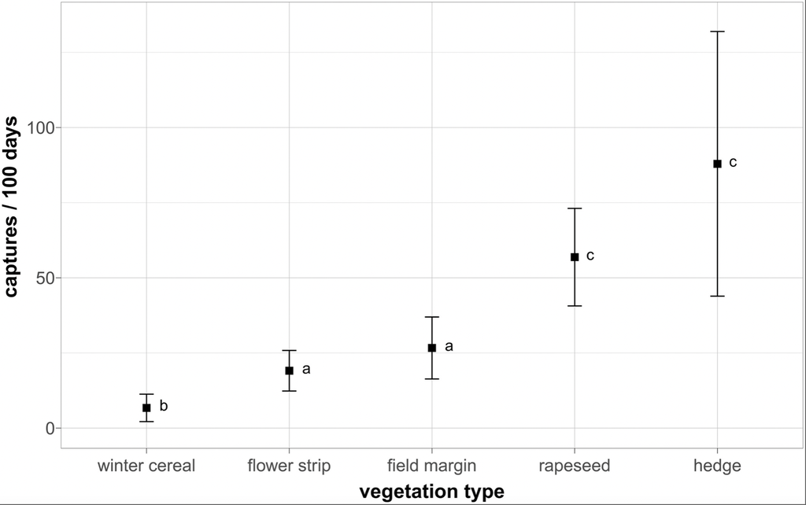

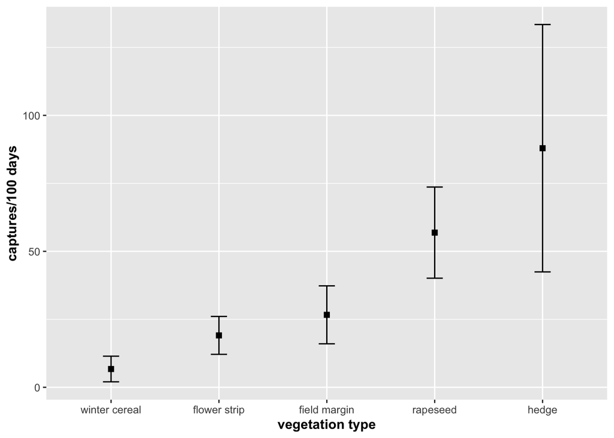

```r
# used ggplot to make the figure; used reorder with the mean to have the vegetation types reorder by increasing order; "allpredators_without_dogs_100" is the column showing the total number of independent predator captures, excluding dogs, extrapolated to 100 active camera days (according to the README)
p <- ggplot(camera_trap_data, aes(x=reorder(Vegetation, allpredators_without_dogs_100, FUN = mean), y=allpredators_without_dogs_100)) +
  stat_summary(geom = "point", fun.y = mean, shape = 15, size = 2) + # makes it a scatter plot and played with the sizing and shape to look closest to the original figure
  ylab("captures/100 days") + # renaming y axis
  xlab("vegetation type") + # renaming x axis
  stat_summary(fun.data = "mean_sdl", fun.args = list(mult = .3), geom = "errorbar", width = 0.15) + # added error bars and manipulated the multitude and width to best reflect the original figure; this might relate to how the CI intervals were also manipulated in the table ?
  scale_x_discrete(labels = c("G" = "winter cereal", "B" = "flower strip", "E" = "field margin", "R" = "rapeseed", "H" = "hedge")) + # renaming the labels in Vegetation
  theme(axis.title = element_text(face = "bold")) # made the axis titles bold
p
```

# Inferential Statistic

Performing a Kruskal-Wallis rank sum test of predator capture rates within each vegetation type. A Kruskal-Wallis rank sum test is similar to a one-way ANOVA but for non-parametric data.

```r
kruskal.test(allpredators_without_dogs_100 ~ Vegetation, data = camera_trap_data)
```

```
##
##  Kruskal-Wallis rank sum test
##
## data:  allpredators_without_dogs_100 by Vegetation
## Kruskal-Wallis chi-squared = 78.308, df = 4, p-value = 3.974e-16
```

```r
kruskal.test(badger_100 ~ Vegetation, data = camera_trap_data)
```

```
##
##  Kruskal-Wallis rank sum test
##
## data:  badger_100 by Vegetation
## Kruskal-Wallis chi-squared = 29.887, df = 4, p-value = 5.16e-06
```

```r
kruskal.test(boar_100 ~ Vegetation, data = camera_trap_data)
```

```
##
##  Kruskal-Wallis rank sum test
##
## data:  boar_100 by Vegetation
## Kruskal-Wallis chi-squared = 18.527, df = 4, p-value = 0.0009733
```

```r
kruskal.test(cats_100 ~ Vegetation, data = camera_trap_data)
```

```
##
##  Kruskal-Wallis rank sum test
##
## data:  cats_100 by Vegetation
## Kruskal-Wallis chi-squared = 12.454, df = 4, p-value = 0.01428
```

```r
kruskal.test(fox_100 ~ Vegetation, data = camera_trap_data)
```

```
##
##  Kruskal-Wallis rank sum test
##
## data:  fox_100 by Vegetation
## Kruskal-Wallis chi-squared = 37.348, df = 4, p-value = 1.527e-07
```

```r
kruskal.test(marten_100 ~ Vegetation, data = camera_trap_data)
```

```
##
##  Kruskal-Wallis rank sum test
##
## data:  marten_100 by Vegetation
## Kruskal-Wallis chi-squared = 22.937, df = 4, p-value = 0.0001304
```

```r
kruskal.test(mouseweasel_100 ~ Vegetation, data = camera_trap_data)
```

```
##
##  Kruskal-Wallis rank sum test
##
## data:  mouseweasel_100 by Vegetation
## Kruskal-Wallis chi-squared = 3.0126, df = 4, p-value = 0.5557
```

```r
kruskal.test(racoon_100 ~ Vegetation, data = camera_trap_data)
```

```
##
##  Kruskal-Wallis rank sum test
##
## data:  racoon_100 by Vegetation
## Kruskal-Wallis chi-squared = 61.155, df = 4, p-value = 1.658e-12
```

```r
kruskal.test(stoat_100 ~ Vegetation, data = camera_trap_data)
```

```
##
##  Kruskal-Wallis rank sum test
##
## data:  stoat_100 by Vegetation
## Kruskal-Wallis chi-squared = 6.1018, df = 4, p-value = 0.1917
```

To compare, here is the list of KW test results from the paper. The values seem to match exactly!

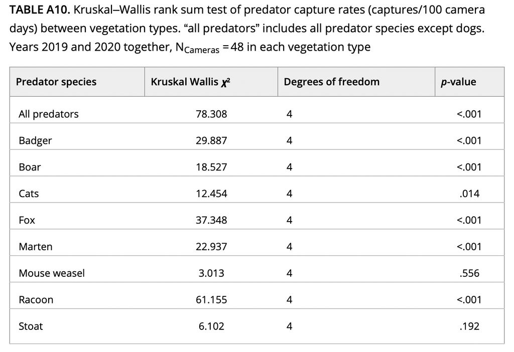

```r
badgerDT <- dunnTest(badger_100 ~ Vegetation, data = camera_trap_data, method="holm", list = TRUE)
badgerDT
```

```
## Dunn (1964) Kruskal-Wallis multiple comparison
```

```
##   p-values adjusted with the Holm method.
```

```
##    Comparison           Z      P.unadj        P.adj
## 1       B - E -2.10356959 3.541601e-02 0.1770800459
## 2       B - G  1.38089165 1.673123e-01 0.6692491127
## 3       E - G  3.48446124 4.931289e-04 0.0039450311
## 4       B - H -2.95517598 3.124907e-03 0.0218743521
## 5       E - H -0.85160640 3.944326e-01 1.0000000000
## 6       G - H -4.33606763 1.450543e-05 0.0001450543
## 7       B - R -2.93821171 3.301115e-03 0.0198066906
## 8       E - R -0.83464213 4.039192e-01 0.8078384713
## 9       G - R -4.31910336 1.566644e-05 0.0001409980
## 10      H - R  0.01696427 9.864651e-01 0.9864651194
```

```r
mapping <- c("B - E" = "Flower Strips - Field Margins",
            "B - G" = "Flower Strips - Winter Cereal",
            "E - G" = "Field Margins - Winter Cereal",
            "B - H" = "Flower Strips - Hedge",
            "E - H" = "Field Margins - Hedge",
            "G - H" = "Winter Cereal - Hedge",
            "B - R" = "Flower Strips - Rapeseed",
            "E - R" = "Field Margins - Rapeseed",
            "G - R" = "Winter Cereal - Rapeseed",
            "H - R" = "Hedge - Rapeseed")
```

For my descriptive analysis, the paper stated that “our data were not normally distributed (Shapiro–Wilk Test, all p < .001, Table A1),” I calculated the Shapiro-Wilk test for each predator to compare the results to Table A1.

```r
# this is calculating the Shapiro Wilk test for all predators from 2019-2020
animals <- as_tibble(camera_trap_data)
predator <- animals %>% select(25:33,35)
results <- lapply(predator, shapiro.test)
results
```

```
## $badger_100
##
##  Shapiro-Wilk normality test
##
## data:  X[[i]]
## W = 0.34981, p-value < 2.2e-16
##
##
## $boar_100
##
##  Shapiro-Wilk normality test
##
## data:  X[[i]]
## W = 0.33097, p-value < 2.2e-16
##
##
## $cats_100
##
##  Shapiro-Wilk normality test
##
## data:  X[[i]]
## W = 0.27104, p-value < 2.2e-16
##
##
## $dog_100
##
##  Shapiro-Wilk normality test
##
## data:  X[[i]]
## W = 0.12638, p-value < 2.2e-16
##
##
## $fox_100
##
##  Shapiro-Wilk normality test
##
## data:  X[[i]]
## W = 0.34682, p-value < 2.2e-16
##
##
```

[output cut: 23 more lines]

```
##
## $stoat_100
##
##  Shapiro-Wilk normality test
##
## data:  X[[i]]
## W = 0.12136, p-value < 2.2e-16
##
##
## $allpredators_without_dogs_100
##
##  Shapiro-Wilk normality test
##
## data:  X[[i]]
## W = 0.45077, p-value < 2.2e-16
```

```r
shapiro.test(camera_trap_data$allpredators_without_dogs_100)
```

```
##
##  Shapiro-Wilk normality test
##
## data:  camera_trap_data$allpredators_without_dogs_100
## W = 0.45077, p-value < 2.2e-16
```

```r
shapiro.test(camera_trap_data$badger_100)
```

```
##
##  Shapiro-Wilk normality test
##
## data:  camera_trap_data$badger_100
## W = 0.34981, p-value < 2.2e-16
```

```r
shapiro.test(camera_trap_data$boar_100)
```

```
##
##  Shapiro-Wilk normality test
##
## data:  camera_trap_data$boar_100
## W = 0.33097, p-value < 2.2e-16
```

```r
shapiro.test(camera_trap_data$cats_100)
```

```
##
##  Shapiro-Wilk normality test
##
## data:  camera_trap_data$cats_100
## W = 0.27104, p-value < 2.2e-16
```

```r
shapiro.test(camera_trap_data$dog_100)
```

```
##
##  Shapiro-Wilk normality test
##
## data:  camera_trap_data$dog_100
## W = 0.12638, p-value < 2.2e-16
```

```r
shapiro.test(camera_trap_data$fox_100)
```

```
##
##  Shapiro-Wilk normality test
##
## data:  camera_trap_data$fox_100
## W = 0.34682, p-value < 2.2e-16
```

```r
shapiro.test(camera_trap_data$marten_100)
```

```
##
##  Shapiro-Wilk normality test
##
## data:  camera_trap_data$marten_100
## W = 0.23388, p-value < 2.2e-16
```

```r
shapiro.test(camera_trap_data$mouseweasel_100)
```

```
##
##  Shapiro-Wilk normality test
##
## data:  camera_trap_data$mouseweasel_100
## W = 0.057273, p-value < 2.2e-16
```

```r
shapiro.test(camera_trap_data$racoon_100)
```

```
##
##  Shapiro-Wilk normality test
##
## data:  camera_trap_data$racoon_100
## W = 0.14139, p-value < 2.2e-16
```

```r
shapiro.test(camera_trap_data$stoat_100)
```

```
##
##  Shapiro-Wilk normality test
##
## data:  camera_trap_data$stoat_100
## W = 0.12136, p-value < 2.2e-16
```

```r
my_data <- as_tibble(camera_trap_data)
predator <- my_data %>% select(25:33)
predator
```

```
## # A tibble: 240 × 9
##    badger_100 boar_100 cats_100 dog_100 fox_100 marten_100 mouseweasel_100
##         <dbl>    <dbl>    <dbl>   <dbl>   <dbl>      <dbl>           <dbl>
##  1       0           0        0    0      14.7           0               0
##  2       0           0        0    4.79   14.4           0               0
##  3       0           0        0    0       0             0               0
##  4       0           0        0    0       0             0               0
##  5       9.50        0        0    0       4.75          0               0
##  6       0           0        0    0       9.55          0               0
##  7       6.20        0        0    0       0             0               0
##  8       4.37        0        0    0       4.37          0               0
##  9       0           0        0    0       5.01          0               0
## 10       0           0        0    0       8.74          0               0
## # ℹ 230 more rows
## # ℹ 2 more variables: racoon_100 <dbl>, stoat_100 <dbl>
```

```r
colnames(predator)
```

```
## [1] "badger_100"      "boar_100"        "cats_100"        "dog_100"
## [5] "fox_100"         "marten_100"      "mouseweasel_100" "racoon_100"
## [9] "stoat_100"
```

```r
names <- predator %>%
  rename(
    Badger = badger_100,
    Boar = boar_100,
    Cat = cats_100,
    Dog = dog_100,
    Fox = fox_100,
    Marten = marten_100,
    MouseWeasel = mouseweasel_100,
    Racoon = racoon_100,
    Stoat = stoat_100
  )
colnames(names)
```

```
## [1] "Badger"      "Boar"        "Cat"         "Dog"         "Fox"
## [6] "Marten"      "MouseWeasel" "Racoon"      "Stoat"
```

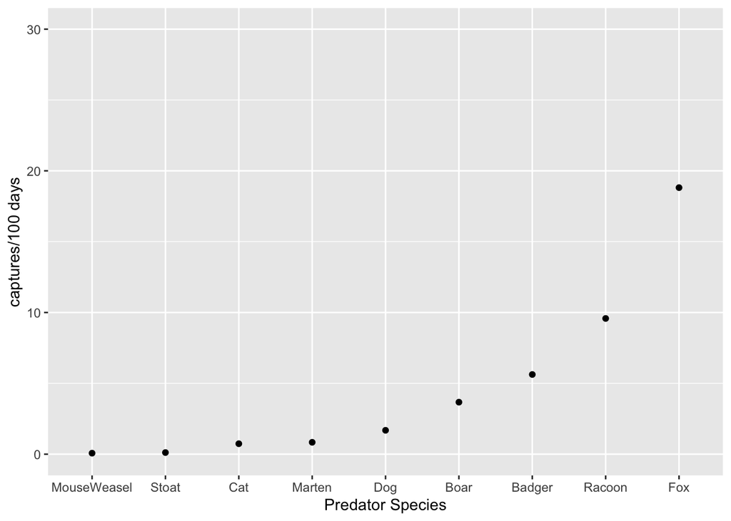

```r
long <- names %>%
  gather(Predator, Captures)


p <- ggplot(long, aes(reorder(Predator, Captures), Captures)) +
  stat_summary(geom = "point", fun.y = mean) +
  ylab("captures/100 days") +
  xlab("Predator Species") +
  expand_limits(y = c(0,30))

p
```

```r
sd(predator$badger_100)
```

```
## [1] 16.01608
```

```r
mean(predator$badger_100)
```

```
## [1] 5.625308
```

```r
head(predator)
```

```
## # A tibble: 6 × 9
##   badger_100 boar_100 cats_100 dog_100 fox_100 marten_100 mouseweasel_100
##        <dbl>    <dbl>    <dbl>   <dbl>   <dbl>      <dbl>           <dbl>
## 1       0           0        0    0      14.7           0               0
## 2       0           0        0    4.79   14.4           0               0
## 3       0           0        0    0       0             0               0
## 4       0           0        0    0       0             0               0
## 5       9.50        0        0    0       4.75          0               0
## 6       0           0        0    0       9.55          0               0
## # ℹ 2 more variables: racoon_100 <dbl>, stoat_100 <dbl>
```

```r
class(predator$badger_100)
```

```
## [1] "numeric"
```

```r
class(long$Captures)
```

```
## [1] "numeric"
```

```r
predator
```

```
## # A tibble: 240 × 9
##    badger_100 boar_100 cats_100 dog_100 fox_100 marten_100 mouseweasel_100
##         <dbl>    <dbl>    <dbl>   <dbl>   <dbl>      <dbl>           <dbl>
##  1       0           0        0    0      14.7           0               0
##  2       0           0        0    4.79   14.4           0               0
##  3       0           0        0    0       0             0               0
##  4       0           0        0    0       0             0               0
##  5       9.50        0        0    0       4.75          0               0
##  6       0           0        0    0       9.55          0               0
##  7       6.20        0        0    0       0             0               0
##  8       4.37        0        0    0       4.37          0               0
##  9       0           0        0    0       5.01          0               0
## 10       0           0        0    0       8.74          0               0
## # ℹ 230 more rows
## # ℹ 2 more variables: racoon_100 <dbl>, stoat_100 <dbl>
```

## Sources:

- [replication paper](https://onlinelibrary.wiley.com/doi/full/10.1002/ece3.9027#ece39027-tbl-0107)
- [how to reorder the x-axis](https://stackoverflow.com/questions/3744178/ggplot2-sorting-a-plot)
- [renaming columns](https://www.datanovia.com/en/lessons/rename-data-frame-columns-in-r/)
- [plotting average values of certain columns in ggplot](https://stackoverflow.com/questions/58415083/plotting-average-values-from-multiple-columns-in-ggplot2)
- [backup option](https://www.geeksforgeeks.org/plot-mean-and-standard-deviation-using-ggplot2-in-r/)
- [dunn’s test](https://www.statology.org/dunns-test-in-r/)
- [rounding decimals](https://stackoverflow.com/questions/9063889/how-to-round-a-data-frame-in-r-that-contains-some-character-variables)
- [KW test](https://www.reneshbedre.com/blog/kruskal-wallis-test.html)
- [KW test](https://stackoverflow.com/questions/28813589/show-kruskal-wallis-test-ranks)
- [dunn test package](https://cran.r-project.org/web/packages/dunn.test/dunn.test.pdf)
- [dunn test table](https://stackoverflow.com/questions/28627603/how-to-create-a-table-as-dunn-test-output-r)
- [ggplot](http://www.sthda.com/english/wiki/ggplot2-scatter-plots-quick-start-guide-r-software-and-data-visualization)
- [error with $ operator](https://www.listendata.com/2022/05/r-error-operator-is-invalid-for-atomic-vectors.html)
- [calculating CI intervals](https://bookdown.org/logan_kelly/r_practice/p09.html)
- [KS test](http://www.sthda.com/english/wiki/kruskal-wallis-test-in-r)
- [Dunn’s Test](https://www.statology.org/dunns-test-in-r/)